# Statistical Rethinking – Week 2

### Modeling

So the final model to be fitted with the data is:

```r
hbar <- mean(df.18$height)

model.1 <- quap(
          alist(
            weight ~ dnorm(mu, sigma),
            mu <- a + b * (height - hbar),
            a ~ dnorm(60, 10),
            b ~ dlnorm(0, 1),
            sigma ~ dunif(0, 10)
            ),
          data=df.18
          )

model.1
```

```r
precis(post.samples, hist=FALSE)
```

```
quap posterior: 10000 samples from model.1
```

|  | mean | sd | 5.5% | 94.5% |
| --- | --- | --- | --- | --- |
| a | 45.00 | 0.23 | 44.63 | 45.36 |
| b | 0.63 | 0.03 | 0.58 | 0.67 |
| sigma | 4.20 | 0.16 | 3.95 | 4.46 |

```r
vcov(model.1)
```

```
                  a             b         sigma
a      5.019158e-02 -2.896840e-08  8.884266e-05
b     -2.896840e-08  8.392887e-04 -8.040908e-06
sigma  8.884266e-05 -8.040908e-06  2.466052e-02
```

```r
diag(vcov(model.1))
```

```
           a            b        sigma
0.0501915835 0.0008392887 0.0246605195
```

```r
cov2cor(vcov(model.1))
```

```
                  a             b        sigma
a      1.000000e+00 -4.463272e-06  0.002525254
b     -4.463272e-06  1.000000e+00 -0.001767455
sigma  2.525254e-03 -1.767455e-03  1.000000000
```

#### Model evaluation

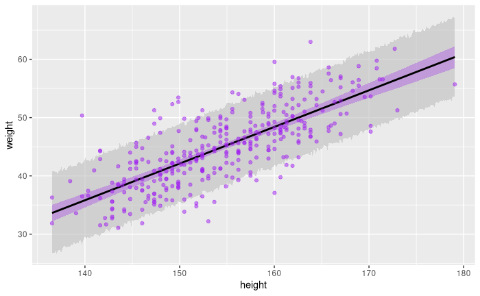

### Predicting the values for individuals 1, 2 and 3

#### Individual 1

```r
pi89
```

```
      5%      94%
28.79284 42.60842
```

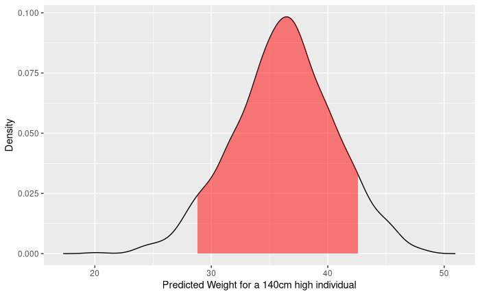

#### Individual 2

```r
mu2 <- link(model.1,data=list(height=160,hbar=hbar))
pi89 <- PI(mu2)
pi89
```

```r
mean(pi89)
```

```r
mu2dens <- with(density(mu2, bw=0.02), tibble(x, y))
mu2dens %>% ggplot(aes(x, y)) +
    geom_line() +
    geom_area(data=subset(mu2dens, x > pi89[1] & x < pi89[2]), fill = "red", alpha=0.5) +
    ylab("Density") +
    xlab("Predicted Weight for a 160cm high individual")
```

#### Individual 3

Any individual 175cm high is predicted to have 56.9 to 58.8 kg.

```r
mu3 <- link(model.1,data=list(height=175,hbar=hbar))
pi89 <- PI(mu3)
pi89
```

```r
mu3dens <- with(density(mu3, bw=0.02), tibble(x, y))
mu3dens %>% ggplot(aes(x, y)) +
    geom_line() +
    geom_area(data=subset(mu3dens, x > pi89[1] & x < pi89[2]), fill = "red", alpha=0.5) +
    ylab("Density") +
    xlab("Predicted Weight for a 175cm high individual")
```

# Exercice 2

Use a linear regression to estimate the total (not just direct) causal effect of each year of growth on weight. Be sure to carefully consider the priors. Try using prior predictive simulation to assess what they imply.

## Answer

As we are interested on the total causal effect of age on weight, we should not stratify the model by height.

### Filtering the data

| height | weight | age | male |
| --- | --- | --- | --- |
| 121.9200 | 19.617854 | 12.0 | 1 |
| 105.4100 | 13.947954 | 8.0 | 0 |
| 86.3600 | 10.489315 | 6.5 | 0 |
| 109.2200 | 15.989118 | 7.0 | 0 |
| 114.3000 | 17.860185 | 11.0 | 1 |
| 121.9200 | 20.411640 | 8.0 | 1 |
| 128.9050 | 23.359988 | 12.0 | 0 |
| 97.7900 | 13.267566 | 5.0 | 0 |
| 110.4900 | 15.422128 | 9.0 | 0 |
| 97.7900 | 12.757275 | 5.0 | 0 |

[output cut: 136 more lines]

There is a linear correlation between age and weight, although due to the method of annotation of age (most of the values seem to have been rounded down with few values with decimal points) there is for each age a lot of variation of weight.

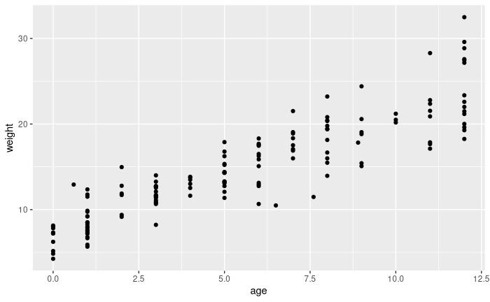

### Weigth

This might be accomplished by: $\alpha \sim \text{LogNormal}(2.5,.6)$.

```r
PI(rlnorm(1e4, 2.5, .6), 0.97)
```

```
       2%       98%
 3.279653 44.533367
```

The data used also provides a hint that on avarage, from the fifth to the fourteenth year, a child gains 2kg per year, so a prior of $\beta \sim \text{LogNormal}(0.5,0.4)$ will allow for a 89% percentile interval of:

```r
PI(rlnorm(1e4, 0.5, 0.4))
```

```
       5%       94%
0.8759304 3.1122783
```

### Modeling

Our model will be so that:

$weight_i \sim \text{Normal}(\mu_i, \sigma)\\\mu_i = \alpha_i + \beta_i*(age_i - \overline{age})\\\alpha_i \sim \text{LogNormal}(2.5,0.6)\\\beta_i \sim \text{LogNormal}(0.5,0.4)\\\sigma \sim \text{Exponential}(1)$

```r
post.samples <- extract.samples(model.2)
precis(post.samples, hist=F)
```

```r
vcov(model.2)
```

```r
diag(vcov(model.2))
```

```r
cov2cor(vcov(model.2))
```

```r
xseq <- seq(from=min(df.13$age), to=max(df.13$age), len=146)
mu <- link(model.2, data=list(age=xseq,abar=abar))
mu.mean <- apply(mu,2,mean)
mu.min <- apply(mu,2,PI,prob=0.99)["1%",]
mu.max <- apply(mu,2,PI,prob=0.99)["100%",]

w_sim <- sim(model.2, data=list(age=xseq,abar=abar))
w_sim.min <- apply(w_sim,2,PI)['5%',]
w_sim.max <- apply(w_sim,2,PI)['94%',]

df.13 %>% ggplot(aes(age,weight)) +
    geom_ribbon(aes(x=xseq, ymax=w_sim.max, ymin=w_sim.min), fill='grey', alpha=0.4) +
    geom_ribbon(aes(x=xseq, ymax=mu.max, ymin=mu.min), fill='purple', alpha=0.3) +
    geom_line(aes(x=xseq, y=mu.mean), size=1, color='black') +
    geom_point(color='purple', alpha=0.5)
```

### Interpretation

The posterior predicts that children will weight on avarage 14.3 to 15kg at age 5 (mean age on the dataset).

```r
post.a <- post.samples$a
(pi89 <- PI(post.a))

a_dens <- with(density(post.a), tibble(x, y))
a_dens %>% ggplot(aes(x,y)) +
    geom_line() +
    geom_area(data=subset(a_dens, x > pi89[1] & x < pi89[2]), fill = "red", alpha=0.5) +
    xlab("posterior intercept α (kg)") +
    ylab('density')
```

It also predicts that children will weight on avarage 1.2 to 1.5 kg more for each year they grow.

```r
post.b <- post.samples$b
(pi89 <- PI(post.b))

b_dens <- with(density(post.b), tibble(x, y))
b_dens %>% ggplot(aes(x,y)) +
    geom_line() +
    geom_area(data=subset(b_dens, x > pi89[1] & x < pi89[2]), fill = "red", alpha=0.5) +
    xlab("posterior slope β (kg/year)") +
    ylab('density')
```

# Exercice 3

Now suppose the causal association between age and weight might be different for boys and girls. Use a single linear regression, with a categorical variable for sex, to estimate the total causal effect of age on weight separately for boys and girls. How do girls and boys differ? Provide one or more posterior summary.

## Answer

The column sex will be mapped so that $\text{female} = 1$ and $\text{male} = 2$.

```r
df.13$sex <- df.13$male+1
```

### Modeling

Our model will be so that:

$weight_i \sim \text{Normal}(\mu_i, \sigma)\\\mu_i = \alpha_{S_i} + \beta_{S_i}*(age_i - \overline{age})\\\alpha_j \sim \text{LogNormal}(2.5,0.6)\\\beta_j \sim \text{LogNormal}(0.5,0.4)\\\sigma \sim \text{Exponential}(1)$

```r
abar <- mean(df.13$age)

model.3 <- quap(
    alist(
       weight ~ dnorm(mu, sigma),
       mu <- a[sex] + b[sex]*(age - abar),
       a[sex] ~ dlnorm(2.5,0.6),
       b[sex] ~ dlnorm(0.5,0.4),
       sigma ~ dexp(1)
    ),
    data=df.13
)

model.3
```

```r
post.samples <- extract.samples(model.3)
precis(post.samples, 2, hist=FALSE)
```

On avarage, boys of a given age will be around one kilogram heavier than girls of the same age. Boys on avarage gain 100 grams of weight per year more than girls.

```r
rethinking::precis_plot(precis(post.samples, 2, hist=FALSE))
```

```r
vcov(model.3)
```

```r
diag(vcov(model.3))
```

```r
cov2cor(vcov(model.3))
```

```r
xseq_m <- seq(from=min(df.13$age), to=max(df.13$age), len=71)
mu_m <- link(model.3, data=list(age=xseq_m,abar=abar,sex=2))
mu_m.mean <- apply(mu_m,2,mean)
mu_m.min <- apply(mu_m,2,PI,prob=0.99)["1%",]
mu_m.max <- apply(mu_m,2,PI,prob=0.99)["100%",]

w_sim_m <- sim(model.3, data=list(age=xseq_m,abar=abar,sex=2))
w_sim_m.min <- apply(w_sim_m,2,PI)['5%',]
w_sim_m.max <- apply(w_sim_m,2,PI)['94%',]

df.13 %>% filter(sex==2) %>% ggplot(aes(age,weight)) +
    geom_ribbon(aes(x=xseq_m, ymax=w_sim_m.max, ymin=w_sim_m.min), fill='grey', alpha=0.4) +
    geom_ribbon(aes(x=xseq_m, ymax=mu_m.max, ymin=mu_m.min), fill='blue', alpha=0.3) +
    geom_line(aes(x=xseq_m, y=mu_m.mean), size=1, color='blue') +
    geom_point(color='blue', alpha=0.5) +
    labs(title="Boys's (0-13 years) weight (kg) by age prediction distribution and data.",
         subtitle = "99% percent interval of mean values in blue shade, 89% percent interval in gray shade.")
```

```r
xseq_f <- seq(from=min(df.13$age), to=max(df.13$age), len=75)
mu_f <- link(model.3, data=list(age=xseq_f,abar=abar,sex=1))
mu_f.mean <- apply(mu_f,2,mean)
mu_f.min <- apply(mu_f,2,PI,prob=0.99)["1%",]
mu_f.max <- apply(mu_f,2,PI,prob=0.99)["100%",]

w_sim_f <- sim(model.3, data=list(age=xseq_f,abar=abar,sex=1))
w_sim_f.min <- apply(w_sim_f,2,PI)['5%',]
w_sim_f.max <- apply(w_sim_f,2,PI)['94%',]

df.13 %>% filter(sex==1) %>% ggplot(aes(age,weight)) +
    geom_ribbon(aes(x=xseq_f, ymax=w_sim_f.max, ymin=w_sim_f.min), fill='grey', alpha=0.4) +
    geom_ribbon(aes(x=xseq_f, ymax=mu_f.max, ymin=mu_f.min), fill='red', alpha=0.3) +
    geom_line(aes(x=xseq_f, y=mu_f.mean), size=1, color='red') +
    geom_point(color='red', alpha=0.5) +
    labs(title="Girl's (0-13 years) weight (kg) by age prediction and data.",
         subtitle = "99% percent interval of mean values in red shade, 89% percent interval in gray shade.")
```

### Causal contrast

#### $\alpha$: weight at 5 years old

```r
a_contrast <- post.samples$a[,2] - post.samples$a[,1]
(pi89 <- PI(a_contrast))

a_contrast_dens <- with(density(a_contrast), tibble(x, y))
a_contrast_dens %>% ggplot(aes(x,y)) +
    geom_line() +
    geom_area(data=subset(a_contrast_dens, x > pi89[1] & x < pi89[2]), fill = "red", alpha=0.5) +
    xlab("posterior intercept α contrast (kg)") +
    ylab('density')
```

#### $\beta$: kilogram per year

The contrast of $\beta$ is the contrast of the posterior weight gain per year for boys and girld. The highest density includes the cases in which boys gain more weight per year (up to 0.270kg ) than girls, but also cases in which the boys and girls’ weight gained in a year is pratically the same or slightly more for girls (up to 50 grams).

```r
b_contrast <- post.samples$b[,2] - post.samples$b[,1]
(pi89 <- PI(b_contrast))

b_contrast_dens <- with(density(b_contrast), tibble(x, y))
b_contrast_dens %>% ggplot(aes(x,y)) +
    geom_line() +
    geom_area(data=subset(b_contrast_dens, x > pi89[1] & x < pi89[2]), fill = "red", alpha=0.5) +
    xlab("posterior slope β contrast (kg/year)") +
    ylab('density')
```

#### $\mu$: mean weight by age

The contrast of $\mu$ is the contrast between the mean weight by age and sex. On avarage, Dobe !Kung San boys are at each age heavier by 0.4 up to 2.5 kilograms than girls.

```r
xseq <- seq(from=0, to=13, length.out=100)
mu_m <- link(model.3, data=list(age=xseq,abar=abar,sex=2))
mu_f <- link(model.3, data=list(age=xseq,abar=abar,sex=1))
mu_contrast <- mu_m - mu_f

tibble(mu=c(mu_m, mu_f), sex=factor(c(rep("M",length(mu_m)), rep("F",length(mu_f))))) %>%
    ggplot(aes(x=mu, color=sex, fill=sex)) +
    geom_density(alpha=0.1, bw=0.07) +
    xlab('posterior weight mean (kg)')
```

```r
pi89 <- PI(mu_contrast)
pi89

mu_contrast_dens <- with(density(mu_contrast), tibble(x, y))
mu_contrast_dens %>% ggplot(aes(x,y)) +
    geom_line() +
    geom_area(data=subset(mu_contrast_dens, x > pi89[1] & x < pi89[2]), fill = "red", alpha=0.5) +
    xlab("posterior mean weight (kg) contrast") +
    ylab('density')
```

### Weight contrast

Dobe !Kung San boys and girls in this simulation don’t appear to have a reliable difference in weight. 33% percent of the girls in the simulation had a higher weight for their age when compared to their masculine counterpart.

```r
w_sim_m <- sim(model.3, data=list(age=c(0:13),abar=abar,sex=2), n=1e4)
w_sim_f <- sim(model.3, data=list(age=c(0:13),abar=abar,sex=1), n=1e4)

tibble(w_sim=c(w_sim_m, w_sim_f), sex=factor(c(rep("M",length(w_sim_m)), rep("F",length(w_sim_f))))) %>%
    ggplot(aes(x=w_sim, color=sex, fill=sex)) +
    xlab("posterior predicted weight (kg)") +
    geom_density(alpha=0.3)
```

```r
w_sim_contrast <- w_sim_m - w_sim_f

w_sim_contrast_dens <- with(density(w_sim_contrast), tibble(x, y))
w_sim_contrast_dens %>% ggplot(aes(x,y)) +
    geom_line() +
    geom_area(data=subset(w_sim_contrast_dens, x <= 0),
              fill = "red",
               alpha=0.5) +
    geom_area(data=subset(w_sim_contrast_dens, x >= 0),
               fill = "blue",
               alpha=0.5) +
    xlab("posterior weight (kg) contrast") +
    ylab('density') +
    annotate("text", x=-10., y=0.06,
               label=scales::percent(sum( w_sim_contrast < 0 ) / length(w_sim_contrast),
                                     accuracy = 0.1),
               color="red",
               alpha=0.5) +
    annotate("text", x=10., y=0.06,
               label=scales::percent(sum( w_sim_contrast > 0 ) / length(w_sim_contrast),
                                      accuracy = 0.1),
               color="blue",
               alpha=0.5)
```